# 2.1_Irithmics_Expectation_Data

180000622

2023-08-05

First let’s import an example Irithmics’ data file

```r
# set working directory to data folder so that from JSON can read the file
setwd("~/MSc_Thesis_Supplementary_Material/data_folder")

ULVR_2021 <- list(Feb = 'JSON forecast for ULVR.XLON 2021-02-04.json',
Apr = 'JSON forecast for ULVR.XLON 2021-04-29.json',
Jul = 'JSON forecast for ULVR.XLON 2021-07-22.json',
Oct =  'JSON forecast for ULVR.XLON 2021-10-21.json')

ULVR_data_set <- lapply(ULVR_2021, fromJSON)
setwd("~/MSc_Thesis_Supplementary_Material")
```

The file is a list containing two elements,

1. forecast dates = the dates over which all the expectation forecasts in the set cover.
2. as_of_dates = a list containing 2 elements. The first is a vecotor of generation dates of each forecast, the second is a list the same length as the generation dates vector with each element containing the Irithmics’ forecast for each day in the forecast range.

The file name also contains the information of the announcement date (which is also the last generation date) and the ticker of the company that the file is generated for.

```r
# extract each element
announcement_date <- lubridate::ymd(ULVR_2021[['Jul']])

ticker <- str_split_1(str_split_1(ULVR_2021[['Jul']], ' ')[4], '.XLON')[1]

forecast_dates <- ULVR_data_set$Jul$forecast_dates
generation_dates <- ULVR_data_set$Jul$as_of_dates$date

forecast_data <- ULVR_data_set$Jul$as_of_dates$data %>% lapply(as.data.frame) %>% bind_cols() %>% set_names(as.character(seq(1, length(ULVR_data_set$Jul$as_of_dates$data))))
```

The first column of this data set is the forecast generated on the first generation day g_1.

We can plot it as a time series:

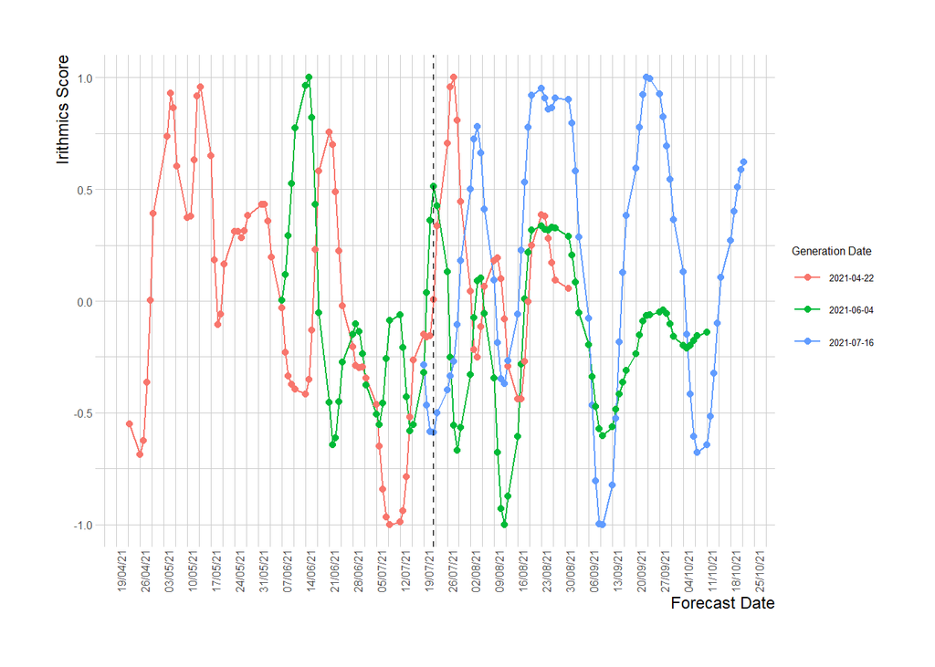

```r
# make data frame with score data and forecast_dates
F1 <- data.frame(forecast_date = forecast_dates, F_1 = forecast_data$`1`,
                 F_30 = forecast_data$`30`,
                 F_60 = forecast_data$`60`)
gen_dates <- c(generation_dates[1], generation_dates[30], generation_dates[60])

# plot as a time series:

F1 %>% pivot_longer(-forecast_date) %>% ggplot(aes(x = as_date(forecast_date), y = value, color = name)) +
  geom_line() + geom_point() +
  geom_vline(xintercept = announcement_date, linetype = 'dashed', alpha = 0.7) +
  scale_x_date(date_breaks = 'week', date_labels = '%d/%m/%y') +
  scale_color_discrete(labels = gen_dates) +
  labs(x = 'Forecast Date',
       y = 'Irithmics Score',
       color = 'Generation Date') +
  theme_ipsum(base_size = 6) +
  theme(axis.text.x = element_text(angle = 90))
```

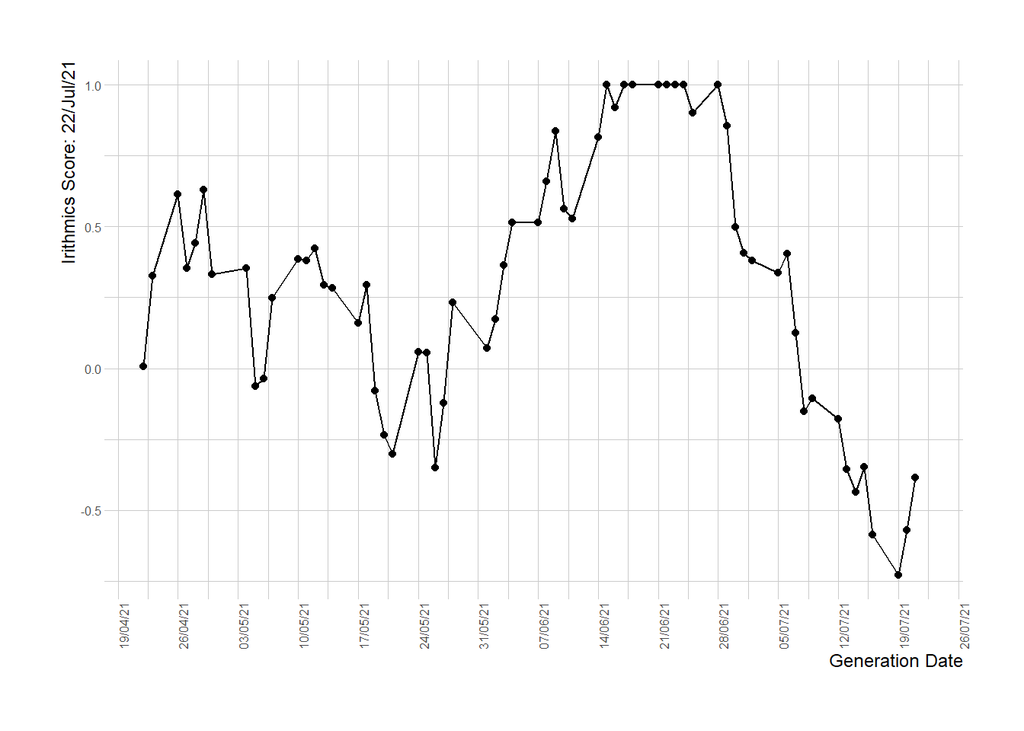

```r
# isolate the row of data that pertains to the announcement date (this is the last generation date)
announce_data <- forecast_data[length(generation_dates), ] %>% unlist(use.names = FALSE)

# make data frame with announce data and generation_dates
announce_df <- data.frame(generation_date = generation_dates, score = announce_data)

# plot as a time series:

announce_df %>% ggplot(aes(x = as_date(generation_date), y = score)) +
  geom_line() + geom_point() +
  scale_x_date(date_breaks = 'week', date_labels = '%d/%m/%y') +
  labs(x = 'Generation Date',
       y = paste('Irithmics Score:', format(announcement_date, '%d/%b/%y'))) +
  theme_ipsum(base_size = 6) +
  theme(axis.text.x = element_text(angle = 90))
```

Now let us construct a color map of the irithmics score:

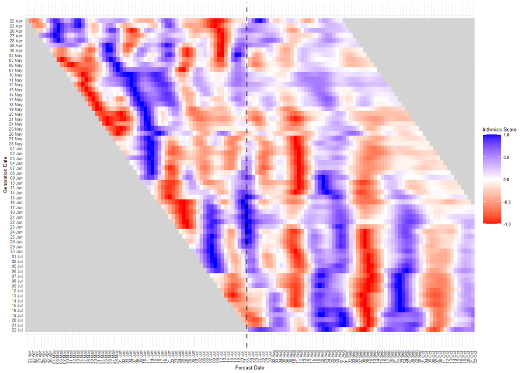

```r
forecast_data %>% mutate(forecast_date = forecast_dates) %>%
  pivot_longer(-forecast_date) %>%
  ggplot(aes(x = as.factor(forecast_date), y = as.numeric(name), fill = value)) + geom_tile() +
  geom_vline(xintercept = as.character(announcement_date),
             color='black', linetype = 'dashed',
             linewidth = 0.6, alpha = 0.5) +

  scale_fill_gradient2(high = 'blue', mid = 'white', low = 'red', na.value = 'lightgrey') +

  scale_y_reverse(breaks = 1:length(generation_dates), labels = as.character(format(as_date(generation_dates), '%d %b'))) +

  scale_x_discrete(labels = format(as_date(forecast_dates), '%d %b'))+

  labs(x = 'Forcast Date',
       y = 'Generation Date',
       fill = 'Irithmics Score') +
  theme_minimal(base_size = 5) +
  theme(axis.text.x = element_text(angle = 90))
```

Now consider ‘reading along the diagonal’ and forming a some time series plots:

```r
h_step_data <- expectation_time_extract(ULVR_data_set$Jul$as_of_dates)

h_step_df <- h_step_data$expect_data
```

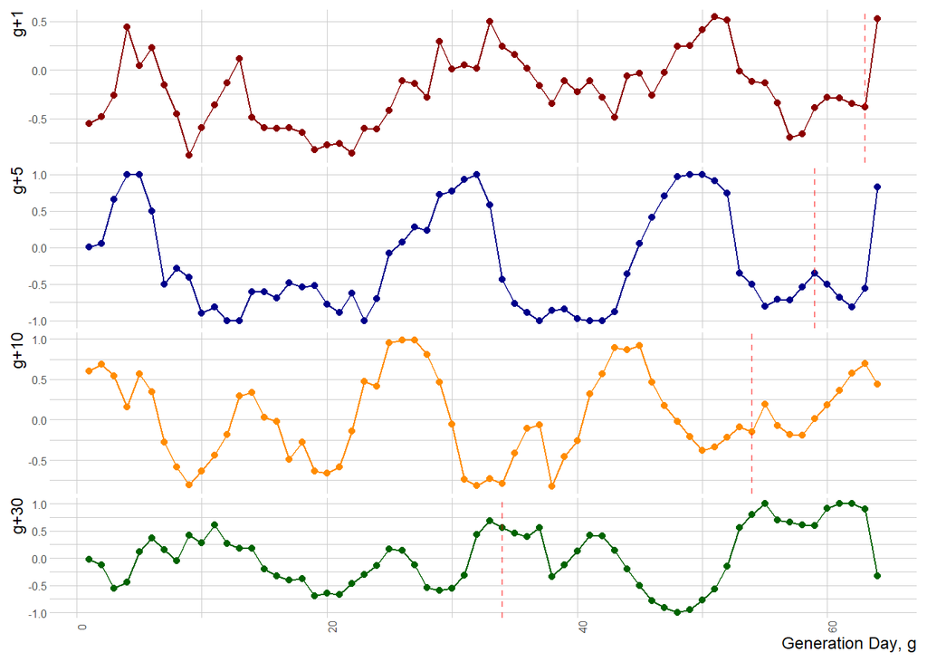

```r
h1 <- h_step_df %>% subset(future_day == 1) %>% pivot_longer(-future_day) %>%
  ggplot(aes(x = as.numeric(name), y = value)) +
  geom_point(color = 'darkred') + geom_line(color = 'darkred') +
  geom_vline(xintercept = (length(generation_dates) - 1), linetype = 'dashed', color = 'red', alpha = 0.5) +
  labs(x = 'Generation Date',
       y = paste('g+1')) +
  theme_ipsum(base_size = 6) +
  theme(axis.text.x = element_blank(),
        axis.ticks.x = element_blank(),
        axis.title.x = element_blank(),
        plot.margin = unit(c(5.5, 5.5, 0, 5.5), "pt"))

h5 <- h_step_df %>% subset(future_day == 5) %>% pivot_longer(-future_day) %>%
  ggplot(aes(x = as.numeric(name), y = value)) +
  geom_point(color = 'darkblue') + geom_line(color = 'darkblue') +
  geom_vline(xintercept = (length(generation_dates) - 5), linetype = 'dashed', color = 'red', alpha = 0.5) +
  labs(x = 'Generation Date',
       y = paste('g+5')) +
  theme_ipsum(base_size = 6) +
  theme(axis.text.x = element_blank(),
        axis.ticks.x = element_blank(),
        axis.title.x = element_blank(),
        plot.margin = unit(c(1, 5.5, 0, 5.5), "pt"))
h10 <- h_step_df %>% subset(future_day == 10) %>% pivot_longer(-future_day) %>%
  ggplot(aes(x = as.numeric(name), y = value)) +
  geom_point(color = 'darkorange') + geom_line(color = 'darkorange') +
  geom_vline(xintercept = (length(generation_dates) - 10), linetype = 'dashed', color = 'red', alpha = 0.5) +
  labs(x = 'Generation Date',
       y = paste('g+10')) +
  theme_ipsum(base_size = 6) +
  theme(axis.text.x = element_blank(),
        axis.ticks.x = element_blank(),
        axis.title.x = element_blank(),
        plot.margin = unit(c(1, 5.5, 0, 5.5), "pt"))

h30 <- h_step_df %>% subset(future_day == 30) %>% pivot_longer(-future_day) %>%
  ggplot(aes(x = as.numeric(name), y = value)) +
  geom_point(color = 'darkgreen') + geom_line(color = 'darkgreen') +
  geom_vline(xintercept = (length(generation_dates) - 30), linetype = 'dashed', color = 'red', alpha = 0.5) +
  labs(x = 'Generation Day, g',
       y = paste('g+30')) +
  theme_ipsum(base_size = 6) +
  theme(axis.text.x = element_text(angle = 90),
        plot.margin = unit(c(1, 5.5, 5.5, 5.5), "pt"))

gridExtra::grid.arrange(h1, h5, h10, h30, nrow = 4)
```

Now make the heatmap_plot:

```r
h_step_hm <- h_step_df %>% pivot_longer(-future_day) %>%
  ggplot(aes(x = as.integer(future_day), y = as.numeric(name), fill = value)) + geom_tile() +

  scale_fill_gradient2(high = 'blue', mid = 'white', low = 'red', na.value = 'lightgrey') +
  scale_x_continuous(breaks = seq(1,90, 3)) +
  scale_y_reverse(breaks = 1:length(generation_dates), labels = as.character(format(as_date(generation_dates), '%d %b'))) +

  labs(x = 'h',
       y = 'Generation Date',
       fill = 'Irithmics Score') +
  theme_minimal(base_size = 5)
```

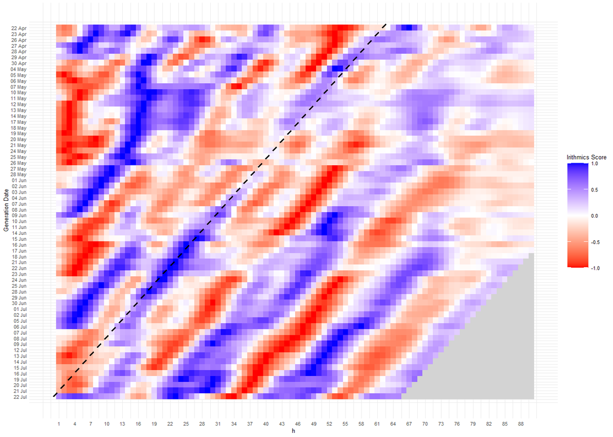

```r
h_step_hm +
  geom_segment(aes(x=0, y=64, xend=63, yend=0),
                         color='black', linetype = 'dashed', linewidth = 0.6, alpha = 0.75)
```

Now consider the following illustration of the merging process between the data sets:

```r
# extract all the forecast data as earlier in the doci=umne tfor the Jult announcement

forecast_data_2021 <- lapply(ULVR_data_set, function(X) { X$as_of_dates$data %>% lapply(as.data.frame) %>% bind_cols() %>% set_names(as.character(seq(1, length(X$as_of_dates$data))))})
```

```r
# plot simple color maps for this data

# February
Feb_cm <- forecast_data_2021$Feb %>% mutate(forecast_date = ULVR_data_set$Feb$forecast_dates) %>%
  pivot_longer(-forecast_date) %>%
  ggplot(aes(x = as.factor(forecast_date), y = as.numeric(name), fill = value)) + geom_tile() +

  scale_fill_gradient2(high = 'blue', mid = 'white', low = 'red', na.value = 'lightgrey') +

  scale_y_reverse(labels = NULL) +

  scale_x_discrete(labels = NULL)+

  labs(x = 'Forcast Date',
       y = 'February',
       fill = 'Irithmics Score') +
  theme_minimal(base_size = 5) +
  theme(axis.text.x = element_blank(),
        axis.ticks.x = element_blank(),
        axis.title.x = element_blank(),
        legend.position = "none",
        plot.margin = unit(c(5.5, 5.5, 0, 5.5), "pt"))
# April
Apr_cm <- forecast_data_2021$Apr %>% mutate(forecast_date = ULVR_data_set$Apr$forecast_dates) %>%
  pivot_longer(-forecast_date) %>%
  ggplot(aes(x = as.factor(forecast_date), y = as.numeric(name), fill = value)) + geom_tile() +

  scale_fill_gradient2(high = 'blue', mid = 'white', low = 'red', na.value = 'lightgrey') +

  scale_y_reverse(labels = NULL) +

  scale_x_discrete(labels = NULL)+

  labs(x = 'Forcast Date',
       y = 'April',
       fill = 'Irithmics Score') +
  theme_minimal(base_size = 5) +
  theme(axis.text.x = element_blank(),
        axis.ticks.x = element_blank(),
        axis.title.x = element_blank(),
        legend.position = "none",
        plot.margin = unit(c(1, 5.5, 0, 5.5), "pt"))

# July
Jul_cm <- forecast_data_2021$Jul %>% mutate(forecast_date = ULVR_data_set$Jul$forecast_dates) %>%
  pivot_longer(-forecast_date) %>%
  ggplot(aes(x = as.factor(forecast_date), y = as.numeric(name), fill = value)) + geom_tile() +

  scale_fill_gradient2(high = 'blue', mid = 'white', low = 'red', na.value = 'lightgrey') +

  scale_y_reverse(labels = NULL) +

  scale_x_discrete(labels = NULL)+

  labs( y = 'July',
       fill = 'Irithmics Score') +
  theme_minimal(base_size = 5) +
  theme(axis.text.x = element_blank(),
        axis.ticks.x = element_blank(),
        axis.title.x = element_blank(),
        legend.position = "none",
        plot.margin = unit(c(1, 5.5, 0, 5.5), "pt"))

# Oct
Oct_cm <- forecast_data_2021$Oct %>% mutate(forecast_date = ULVR_data_set$Oct$forecast_dates) %>%
  pivot_longer(-forecast_date) %>%
  ggplot(aes(x = as.factor(forecast_date), y = as.numeric(name), fill = value)) + geom_tile() +

  scale_fill_gradient2(high = 'blue', mid = 'white', low = 'red', na.value = 'lightgrey') +

  scale_y_reverse(labels = NULL) +

  scale_x_discrete(labels = NULL)+

  labs(x = 'Forcast Date',
       y = 'October',
       fill = 'Irithmics Score') +
  theme_minimal(base_size = 5) +
  theme(legend.position = "none",
        axis.text.x = element_text(angle = 90),
        plot.margin = unit(c(1, 5.5, 5.5, 5.5), "pt"))
```

```r
merged_data <- read_rds('merged_raw_data.rds')
ULVR <- merged_data$ULVR
# select the longer period 2020-11-04 -> 2021
merged_set <- ULVR[[2]]

# extract using a left-alligned UDF functions
expectation_time_set <- expectation_time_extract(merged_set)

# drop relative date for shifting
left_alligned_data <- expectation_time_set$expect_data %>% select(-future_day)

# set the lengths of each column (forecast) to be the whole foreacst range
# forecast range is the whole generation period + the forecast length of the last forecast
# get forecast length of last forecast
last_length <- expectation_time_set$expect_data%>%
  select(ncol(expectation_time_set$expect_data)) %>% na.omit() %>%
  unlist(use.names = FALSE) %>% length()
# get forecast range N.B. range is one less as it includes the forecast generation day in length of generation days
forecast_range <- length(merged_set$date) + last_length - 1

# assign lengths
left_alligned_data <- apply(left_alligned_data, MARGIN = 2, function (x) {length(x) <- forecast_range; x})

# now shift each column along by 1
shifted_data <- foreach(i = seq(1, ncol(left_alligned_data)), .combine = cbind) %do% {
  # select column i, and shift it back by i spaces
  data.table::shift(left_alligned_data[,i], n = i, fill = NA, type = 'lag')
}

# set names to be generation date number (and coerce into df)
shifted_data <- as.data.frame(shifted_data)
shifted_data <- set_names(as.data.frame(shifted_data), seq(1, ncol(shifted_data)))

# now select foreacst dates and add them to the df
forecast_dates <- ULVR$forecast_dates

# get index in forecast dates where first generation date occurs
start <- match(as_date(merged_set$date)[1], as_date(forecast_dates)) %>% unlist(use.names = FALSE) %>% na.omit()

# extract forecast dates N.B. -1 to account for double counting
forecast_window <- forecast_dates[start:(start+forecast_range - 1)] %>% as_date()

# add forecast dates as a variable to pivot around
shifted_data$forecast_date <- forecast_window

# extract announcement dates
announcement_dates <- ULVR$announcement_dates
# get mtching announcements
match_announcements <- announcement_dates[match(as_date(merged_set$date), announcement_dates)] %>% na.omit()
```

Now plot a standard Irithmics heatmap of the data, noting the announcement dates.

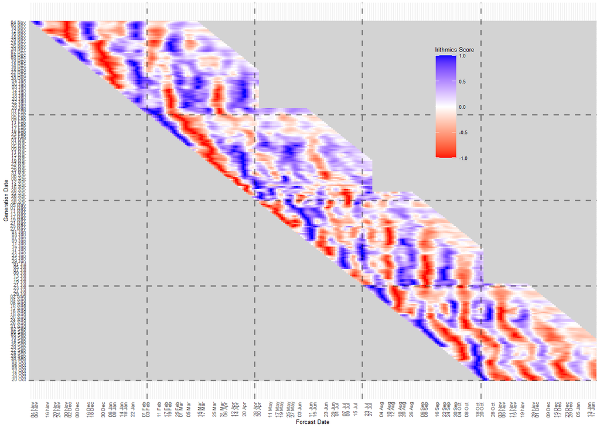

```r
long <- shifted_data %>% pivot_longer(-as.character('forecast_date'))

# make a less cramped set of labels by setting every second one to blank
xlabels <- format(sort(unique(long$forecast_date)), '%d %b')
xlabels[seq(2, length(xlabels), 2)] <- ""
xlabels[seq(2, length(xlabels), 3)] <- ""
xlabels[seq(2, length(xlabels), 5)] <- ""

ylabels <- as.character(format(as_date(merged_set$date), '%d %b'))
ylabels[seq(2, length(ylabels), 2)] <- ""

merged_2021_cm <- long %>%
  ggplot(aes(x = as.factor(forecast_date), y = as.numeric(name), fill = value)) +
  geom_tile() +

   scale_x_discrete(labels = xlabels) +
   scale_fill_gradient2(high = 'blue', mid = 'white', low = 'red', na.value = 'lightgrey') +

  scale_y_reverse(breaks = 1:length(ylabels), labels = ylabels) +

  labs(x = 'Forcast Date',
       y = 'Generation Date',
       fill = 'Irithmics Score') +
  theme_minimal(base_size = 5) +
  theme(axis.text.x = element_text(angle = 90),
        legend.position = c(0.75, 0.75)) +
  # add announcements
  geom_vline(data = as.data.frame(as.character(match_announcements)),
             aes(xintercept = as.character(match_announcements)),
             color='black', linetype = 'dashed',
             linewidth = 0.6, alpha = 0.4) +
  geom_hline(data = as.data.frame(as.character(match_announcements)),
             aes(yintercept = match(announcement_dates, as_date(merged_set$date)) %>% na.omit()),
             color='black', linetype = 'dashed',
             linewidth = 0.6, alpha = 0.4)


merged_2021_cm
```

Arrange in a grid:

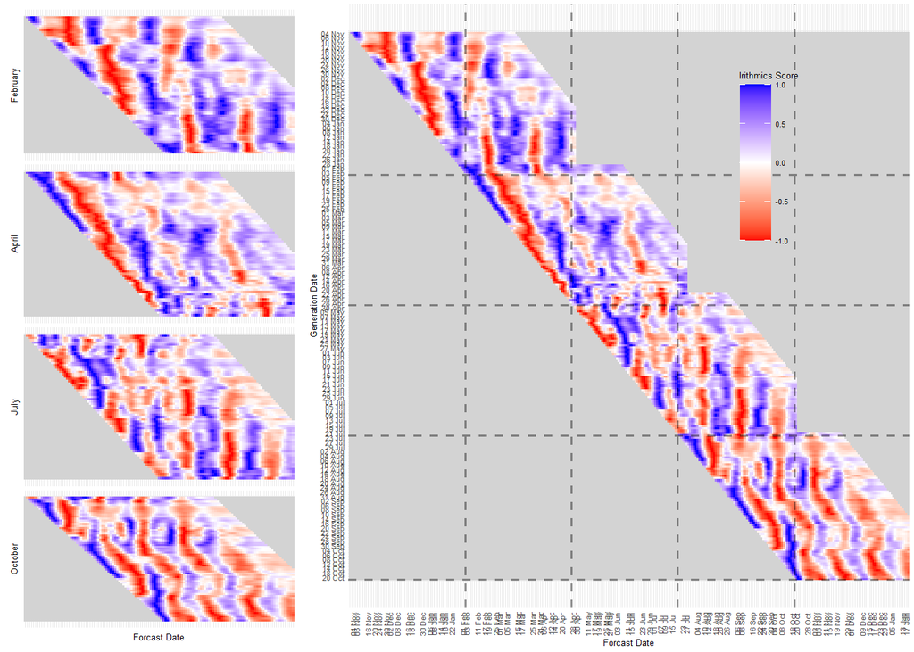

```r
grid.arrange(arrangeGrob(Feb_cm, Apr_cm, Jul_cm, Oct_cm, nrow = 4), merged_2021_cm, ncol = 2, widths = c(1,2))
```

# Data Merging Step

```r
# get the list of big files
big_files <- data.frame(file_names = read_rds('big_file_list.rds'))

# get a list of unique tickers
tickers <- lapply(big_files[,1], function(file) str_split_1(file, pattern = ' ')[4]) %>%
                  unique() %>% unlist(use.names = FALSE)

# get lists of files for each ticker
# N.B. exact string matching to avoid issues like 'BA.XLON' capturing 'HSBA.XLON'incorrectly
files_by_ticker <- lapply(tickers, function(ticker) {
  file_names <- big_files[grepl(paste0('\\b',ticker,'\\b'), big_files$file_names),]
})

# set names to be tickers (and drop the XLON)
files_by_ticker <- set_names(files_by_ticker, lapply(tickers, function(x){str_split_1(x, '.XLON')[1]}))  # set names to be ticker

# extract the announcemnt dates for each file and store it with each ticker
files_by_ticker <- lapply(files_by_ticker, function(file_list) {
  list(file_names = file_list,
       announcement = lubridate::ymd(file_list))
} )

# for each list of files read in the JSON and merge
setwd("~/MSc_Thesis_Supplementary_Material/data_folder")

unmerged_data <- vector('list', 91)
for (i in 1:length(files_by_ticker)) {

  # get file names and extract the JSON file
  file_list <- files_by_ticker[[i]][[1]]
  files <- lapply(file_list, jsonlite::fromJSON)

  unmerged_data[[i]] <- files
}
# set names of groups of lists to be the corresponding ticker
unmerged_data <- set_names(unmerged_data, lapply(tickers, function(x){str_split_1(x, '.XLON')[1]}))  # set names to be ticker

setwd("~/MSc_Thesis_Supplementary_Material")
```

```r
# we can now get the number of files per ticker

lengths <- data.frame(ticker = names(unmerged_data), nfiles = lapply(unmerged_data, length) %>% unlist(use.names = FALSE))

n_forecasts <- foreach(company = unmerged_data) %do% {
  n_forecasts <- lapply(company, function(X) {X$as_of_dates$date %>% length()})

  data.frame(mean_forecasts = mean(unlist(n_forecasts, use.names = FALSE)),
             median_forecasts = median(unlist(n_forecasts, use.names = FALSE)),
             min_forecasts = min(unlist(n_forecasts, use.names = FALSE)),
             max_forecasts = max(unlist(n_forecasts, use.names = FALSE)))
}
n_forecasts <- n_forecasts %>% set_names(names(unmerged_data)) %>% bind_rows(.id = 'ticker')

unmerged_n_forecasts <- merge(lengths, n_forecasts, by = 'ticker')
```

```r
# we can do the same for the merged data set
# N.B in its construction two variables forecast_dates_and announcemnt dates were added to each
# ticker of merged data. Therefore the number of forecast sets is length - 2
merged_lengths <- data.frame(ticker = names(merged_data), nfiles = lapply(merged_data, function(X){length(X) - 2}) %>% unlist(use.names = FALSE))

merged_n_forecasts <- foreach(company = merged_data) %do% {
  forecasts <- company[(names(company) %in% c('announcement_dates', 'forecast_dates')) == FALSE]
  n_forecasts <- lapply(forecasts, function(X) {X$date %>% length()})

  data.frame(mean_forecasts = mean(unlist(n_forecasts, use.names = FALSE)),
             median_forecasts = median(unlist(n_forecasts, use.names = FALSE)),
             min_forecasts = min(unlist(n_forecasts, use.names = FALSE)),
             max_forecasts = max(unlist(n_forecasts, use.names = FALSE)))
}
merged_n_forecasts <- merged_n_forecasts %>% set_names(names(merged_data)) %>% bind_rows(.id = 'ticker')

merged_n_forecasts <- merge(merged_lengths, merged_n_forecasts, by = 'ticker')
```

```r
summary_table <- data.frame(unmerged = unmerged_n_forecasts %>% summarise(mean_nfiles = mean(nfiles),
                                                                      mean_mean_forecasts = mean(mean_forecasts),

                                                                      max_forecast = max(max_forecasts)) %>% t(),
                            merged = merged_n_forecasts %>% summarise(mean_nfiles = mean(nfiles),
                                                                      mean_mean_forecasts = mean(mean_forecasts),

                                                                      max_forecast = max(max_forecasts)) %>% t()
)

summary_table %>% round()
```

```
##                     unmerged merged
## mean_nfiles               10      5
## mean_mean_forecasts       63    109
## max_forecast              67    254
```

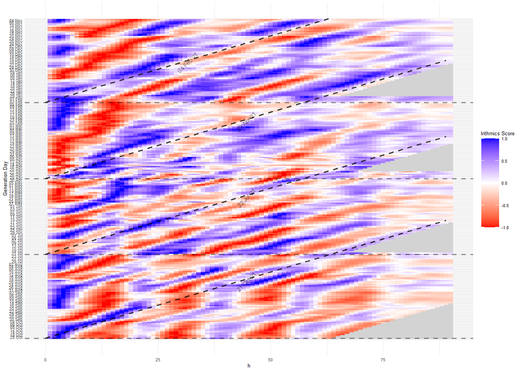

```r
merged_left_alligned_plot <- hm_plot_exp_space(expectation_time_set$expect_data)

merged_left_alligned_plot <- add_announcements_diag(merged_left_alligned_plot, expectation_time_set, announcement_dates = announcement_dates, merged_forecasts = merged_data$ULVR[[2]])

ylabels <- as.character(format(as_date(merged_set$date), '%d %b'))
ylabels[seq(2, length(ylabels), 2)] <- ""

merged_left_alligned_plot +
  scale_y_reverse(breaks = 1:length(ylabels), labels = ylabels) +
  geom_hline(data = as.data.frame(as.character(match_announcements)),
             aes(yintercept = match(announcement_dates, as_date(merged_set$date)) %>% na.omit()),
             color='black', linetype = 'dashed',
             linewidth = 0.6, alpha = 0.4) +
  labs(x = "h")+
  theme_minimal(base_size = 5)
```